# AIML_ML_Project_Full_Code_Notebook_working_copy

## Problem Statement

### Context

AllLife Bank is a US bank that has a growing customer base. The majority of these customers are liability customers (depositors) with varying sizes of deposits. The number of customers who are also borrowers (asset customers) is quite small, and the bank is interested in expanding this base rapidly to bring in more loan business and in the process, earn more through the interest on loans. In particular, the management wants to explore ways of converting its liability customers to personal loan customers (while retaining them as depositors).

A campaign that the bank ran last year for liability customers showed a healthy conversion rate of over 9% success. This has encouraged the retail marketing department to devise campaigns with better target marketing to increase the success ratio.

You as a Data scientist at AllLife bank have to build a model that will help the marketing department to identify the potential customers who have a higher probability of purchasing the loan.

### Objective

To predict whether a liability customer will buy personal loans, to understand which customer attributes are most significant in driving purchases, and identify which segment of customers to target more.

### Data Dictionary

- `ID`: Customer ID
- `Age`: Customer’s age in completed years
- `Experience`: #years of professional experience
- `Income`: Annual income of the customer (in thousand dollars)
- `ZIP Code`: Home Address ZIP code.
- `Family`: the Family size of the customer
- `CCAvg`: Average spending on credit cards per month (in thousand dollars)
- `Education`: Education Level. 1: Undergrad; 2: Graduate;3: Advanced/Professional
- `Mortgage`: Value of house mortgage if any. (in thousand dollars)
- `Personal_Loan`: Did this customer accept the personal loan offered in the last campaign? (0: No, 1: Yes)
- `Securities_Account`: Does the customer have securities account with the bank? (0: No, 1: Yes)
- `CD_Account`: Does the customer have a certificate of deposit (CD) account with the bank? (0: No, 1: Yes)
- `Online`: Do customers use internet banking facilities? (0: No, 1: Yes)
- `CreditCard`: Does the customer use a credit card issued by any other Bank (excluding All life Bank)? (0: No, 1: Yes)

## Importing necessary libraries

```python
# Installing the libraries with the specified version.
!pip install numpy==1.25.2 pandas==1.5.3 matplotlib==3.7.1 seaborn==0.13.1 scikit-learn==1.2.2 sklearn-pandas==2.2.0 -q --user
```

[output not shown]

**Note**:

1. After running the above cell, kindly restart the notebook kernel (for Jupyter Notebook) or runtime (for Google Colab), write the relevant code for the project from the next cell, and run all cells sequentially from the next cell.
2. On executing the above line of code, you might see a warning regarding package dependencies. This error message can be ignored as the above code ensures that all necessary libraries and their dependencies are maintained to successfully execute the code in this notebook.

```python
# Libraries to help with reading and manipulating data
import numpy as np
import pandas as pd

# Libraries to help with data visualization
import matplotlib.pyplot as plt
import seaborn as sns
import plotly.express as px

# Removes the limit for the number of displayed columns
pd.set_option("display.max_columns", None)
# Sets the limit for the number of displayed rows
pd.set_option("display.max_rows", 200)

# Libraries for scaling numerical features
from sklearn.preprocessing import StandardScaler

# to perform k-means clustering
from sklearn.cluster import KMeans

# to perform silhouette analysis
from sklearn.metrics import silhouette_score

# to perform t-SNE
from sklearn.manifold import TSNE

# to define a common seed value to be used throughout
RS=0

# to suppress unnecessary warnings
import warnings
warnings.filterwarnings("ignore")
```

## Loading the dataset

```python
# uncomment and run the below code snippets if the dataset is present in the Google Drive
from google.colab import drive
drive.mount('/content/drive')
```

```python
# loading data into a pandas dataframe
customer_data = pd.read_csv("/content/drive/MyDrive/Colab Notebooks/Portfolio/LoanCampaign/Loan_Modelling.csv")
```

```python
# copying the data to another variable to avoid any changes to original data
df = customer_data.copy()
```

## Data Overview

- Observations
- Sanity checks

### Displaying the first few rows of the data

```python
# viewing the first 5 rows of the data
df.head()
```

|  | ID | Age | Experience | Income | ZIPCode | Family | CCAvg | Education | Mortgage | Personal_Loan | Securities_Account | CD_Account | Online | CreditCard |
| --- | --- | --- | --- | --- | --- | --- | --- | --- | --- | --- | --- | --- | --- | --- |
| 0 | 1 | 25 | 1 | 49 | 91107 | 4 | 1.6 | 1 | 0 | 0 | 1 | 0 | 0 | 0 |
| 1 | 2 | 45 | 19 | 34 | 90089 | 3 | 1.5 | 1 | 0 | 0 | 1 | 0 | 0 | 0 |
| 2 | 3 | 39 | 15 | 11 | 94720 | 1 | 1.0 | 1 | 0 | 0 | 0 | 0 | 0 | 0 |
| 3 | 4 | 35 | 9 | 100 | 94112 | 1 | 2.7 | 2 | 0 | 0 | 0 | 0 | 0 | 0 |
| 4 | 5 | 35 | 8 | 45 | 91330 | 4 | 1.0 | 2 | 0 | 0 | 0 | 0 | 0 | 1 |

### Checking the shape of the dataset

```python
df.shape
```

```
(5000, 14)
```

- The dataset has 5000 rows and 14 columns

### Checking the data types of the columns for the dataset.

```python
df.info()
```

```
<class 'pandas.core.frame.DataFrame'>
RangeIndex: 5000 entries, 0 to 4999
Data columns (total 14 columns):
 #   Column              Non-Null Count  Dtype
---  ------              --------------  -----
 0   ID                  5000 non-null   int64
 1   Age                 5000 non-null   int64
 2   Experience          5000 non-null   int64
 3   Income              5000 non-null   int64
 4   ZIPCode             5000 non-null   int64
 5   Family              5000 non-null   int64
 6   CCAvg               5000 non-null   float64
 7   Education           5000 non-null   int64
 8   Mortgage            5000 non-null   int64
 9   Personal_Loan       5000 non-null   int64
 10  Securities_Account  5000 non-null   int64
 11  CD_Account          5000 non-null   int64
 12  Online              5000 non-null   int64
 13  CreditCard          5000 non-null   int64
dtypes: float64(1), int64(13)
memory usage: 547.0 KB
```

- All cloumns are numeric

### Checking for missing values

```python
# checking for missing values
df.isnull().sum()
```

|  | 0 |
| --- | --- |
| ID | 0 |
| Age | 0 |
| Experience | 0 |
| Income | 0 |
| ZIPCode | 0 |
| Family | 0 |
| CCAvg | 0 |
| Education | 0 |
| Mortgage | 0 |
| Personal_Loan | 0 |
| Securities_Account | 0 |
| CD_Account | 0 |
| Online | 0 |
| CreditCard | 0 |

**dtype:** int64

### Checking for duplicate values

```python
# checking the number of unique values in each column
df.nunique()
```

|  | 0 |
| --- | --- |
| ID | 5000 |
| Age | 45 |
| Experience | 47 |
| Income | 162 |
| ZIPCode | 467 |
| Family | 4 |
| CCAvg | 108 |
| Education | 3 |
| Mortgage | 347 |
| Personal_Loan | 2 |
| Securities_Account | 2 |
| CD_Account | 2 |
| Online | 2 |
| CreditCard | 2 |

**dtype:** int64

- No duplicate customer IDs identified

### Checking for duplicate rows

```python
# Check for duplicate rows
duplicate_rows = df[df.duplicated()]
print(f"Number of fully duplicate rows: {duplicate_rows.shape[0]}")
```

```
Number of fully duplicate rows: 0
```

### Cleaning/Sanitizing and dropping cloumns that add no value to correlation or machine learning to reduce noise

```python
# Fixing and standardizing column names
df.columns = [c.strip().lower().replace(" ", "_") for c in df.columns]
# Create a new dataframe without the ID column
df2 = df.drop(columns=['id'], errors='ignore').copy()
# Verify that ID is dropped
print("Columns in df2:\n", df2.columns.tolist())
df2.shape
```

```
Columns in df2:
 ['age', 'experience', 'income', 'zipcode', 'family', 'ccavg', 'education', 'mortgage', 'personal_loan', 'securities_account', 'cd_account', 'online', 'creditcard']
```

```
(5000, 13)
```

```python
# Let's look at the statistical summary of the data
df2.describe().T
```

|  | count | mean | std | min | 25% | 50% | 75% | max |
| --- | --- | --- | --- | --- | --- | --- | --- | --- |
| age | 5000.0 | 45.338400 | 11.463166 | 23.0 | 35.0 | 45.0 | 55.0 | 67.0 |
| experience | 5000.0 | 20.104600 | 11.467954 | -3.0 | 10.0 | 20.0 | 30.0 | 43.0 |
| income | 5000.0 | 73.774200 | 46.033729 | 8.0 | 39.0 | 64.0 | 98.0 | 224.0 |
| zipcode | 5000.0 | 93169.257000 | 1759.455086 | 90005.0 | 91911.0 | 93437.0 | 94608.0 | 96651.0 |
| family | 5000.0 | 2.396400 | 1.147663 | 1.0 | 1.0 | 2.0 | 3.0 | 4.0 |
| ccavg | 5000.0 | 1.937938 | 1.747659 | 0.0 | 0.7 | 1.5 | 2.5 | 10.0 |
| education | 5000.0 | 1.881000 | 0.839869 | 1.0 | 1.0 | 2.0 | 3.0 | 3.0 |
| mortgage | 5000.0 | 56.498800 | 101.713802 | 0.0 | 0.0 | 0.0 | 101.0 | 635.0 |
| personal_loan | 5000.0 | 0.096000 | 0.294621 | 0.0 | 0.0 | 0.0 | 0.0 | 1.0 |
| securities_account | 5000.0 | 0.104400 | 0.305809 | 0.0 | 0.0 | 0.0 | 0.0 | 1.0 |
| cd_account | 5000.0 | 0.060400 | 0.238250 | 0.0 | 0.0 | 0.0 | 0.0 | 1.0 |
| online | 5000.0 | 0.596800 | 0.490589 | 0.0 | 0.0 | 1.0 | 1.0 | 1.0 |
| creditcard | 5000.0 | 0.294000 | 0.455637 | 0.0 | 0.0 | 0.0 | 1.0 | 1.0 |

Statistical Summary Observations

Income

- Wide range ($8K – $224K) with a high mean (~$74K).
- Suggests strong variation across customers, which could impact ability/willingness to take loans.

CCAvg (Credit Card Spending)

- Right-skewed distribution, mean ~$1.9K but max at $10K.
- Indicates a segment of heavy spenders who may be more likely to consider loans.

Education

- Encoded as 1–3, with mean ~1.9.
- Many customers are graduate or professional level, which often correlates with higher income and financial product adoption.

CD Account

- Small proportion (~6%) of customers hold a CD account.
- Even though minority, this feature stands out as it differentiates customers into distinct groups.

## Exploratory Data Analysis.

```
Unique regions derived from ZIP codes: ['91' '90' '94' '92' '93' '95' '96']

Personal Loan Acceptance Distribution:
 personal_loan
0    4520
1     480
Name: count, dtype: int64
```

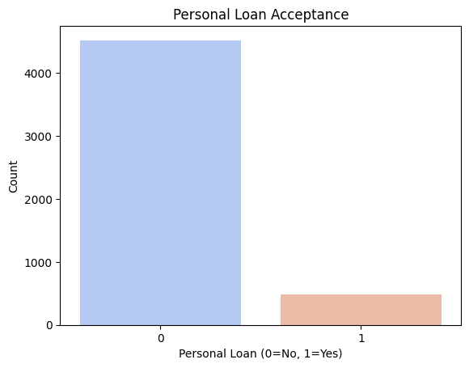

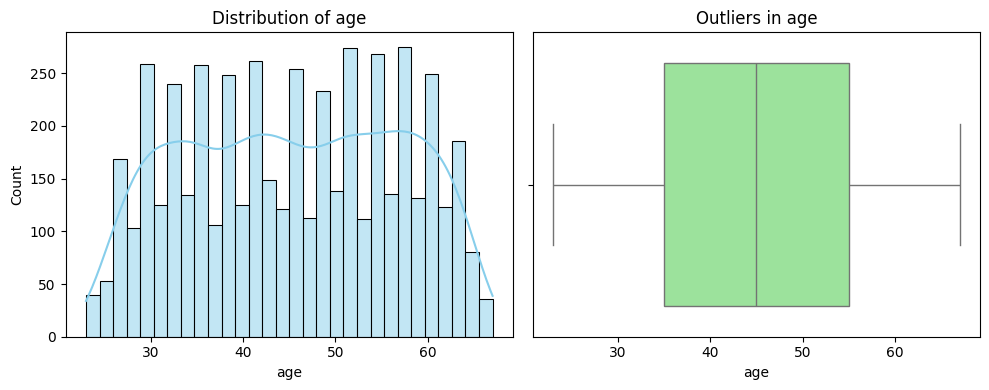

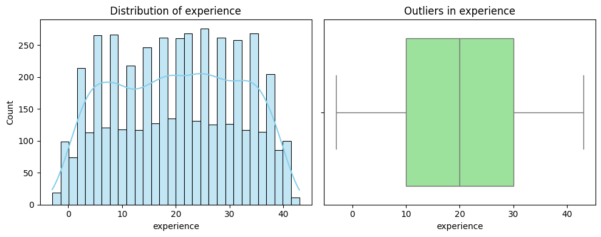

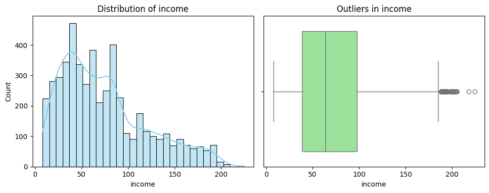

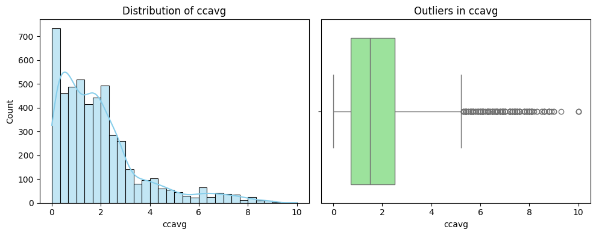

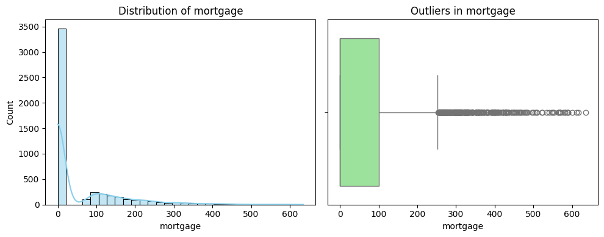

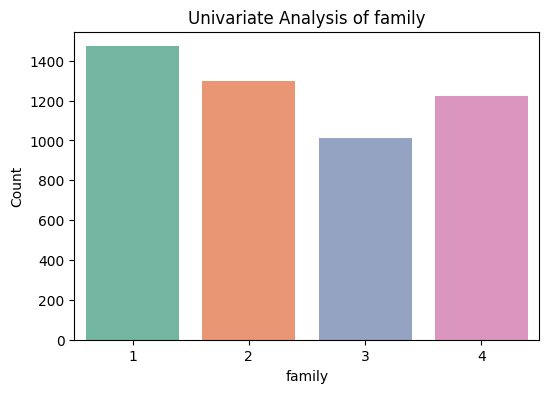

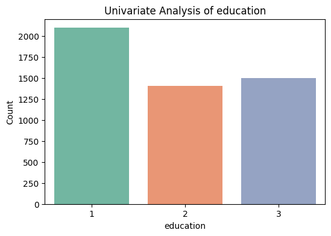

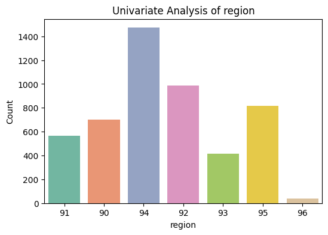

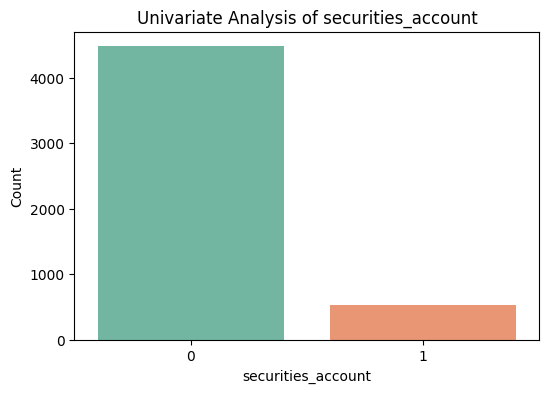

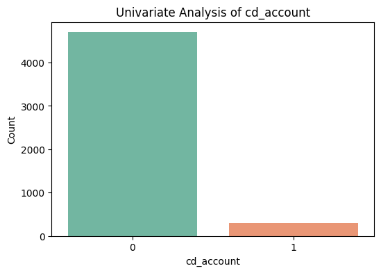

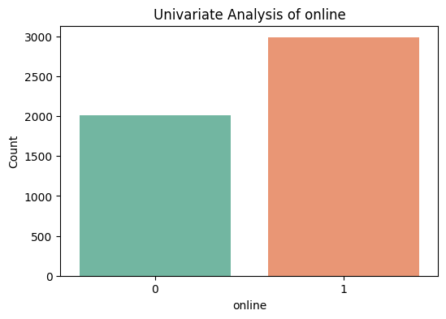

[28 more figures not shown]

```
Top correlations with Personal Loan:

personal_loan         1.000000
income                0.502462
ccavg                 0.366889
cd_account            0.316355
mortgage              0.142095
securities_account    0.021954
online                0.006278
creditcard            0.002802
experience           -0.007413
age                  -0.007726
Name: personal_loan, dtype: float64

Chi-Square Tests for Categorical Variables vs Personal Loan

family: Chi2=29.68, p=0.0000
education: Chi2=111.24, p=0.0000
region: Chi2=0.60, p=0.9964
securities_account: Chi2=2.17, p=0.1405
cd_account: Chi2=495.90, p=0.0000
online: Chi2=0.16, p=0.6929
creditcard: Chi2=0.02, p=0.8844
```

```python
# ================================
# Exploratory Data Analysis (EDA)
# ================================

import matplotlib.pyplot as plt
import seaborn as sns
import pandas as pd
from scipy.stats import chi2_contingency

# ------------------------------------------------
# 0. Create a new 'region' variable from ZIP code
# ------------------------------------------------
# Keep first 2 digits of ZIP → broad regions (7–8 categories)
df2['region'] = df2['zipcode'].astype(str).str[:2]
print("Unique regions derived from ZIP codes:", df2['region'].unique())
# Drop zipcode to reduce specificity
df2 = df2.drop(columns=['zipcode'])

# -------------------------
# 1. Target Variable Distribution
# -------------------------
loan_counts = df2['personal_loan'].value_counts()
print("\nPersonal Loan Acceptance Distribution:\n", loan_counts)

sns.countplot(x='personal_loan', data=df2, palette="coolwarm")
plt.title("Personal Loan Acceptance")
plt.xlabel("Personal Loan (0=No, 1=Yes)")
plt.ylabel("Count")
plt.show()

# ------------------------------------------------
# 2. Univariate Analysis - Continuous Variables
# ------------------------------------------------
continuous_vars = ['age', 'experience', 'income', 'ccavg', 'mortgage']

for col in continuous_vars:
    plt.figure(figsize=(10,4))

    plt.subplot(1,2,1)
    sns.histplot(df2[col], bins=30, kde=True, color="skyblue")
    plt.title(f"Distribution of {col}")
    plt.xlabel(col)

    plt.subplot(1,2,2)
    sns.boxplot(x=df2[col], color="lightgreen")
    plt.title(f"Outliers in {col}")
    plt.xlabel(col)

    plt.tight_layout()
    plt.show()

# ------------------------------------------------
# 3. Univariate Analysis - Categorical Variables
# ------------------------------------------------
categorical_vars = ['family', 'education', 'region',
                    'securities_account', 'cd_account', 'online', 'creditcard']

for col in categorical_vars:
    plt.figure(figsize=(6,4))
    sns.countplot(x=col, data=df2, palette="Set2")
    plt.title(f"Univariate Analysis of {col}")
    plt.xlabel(col)
    plt.ylabel("Count")
    plt.show()

# ------------------------------------------------
# 4. Bivariate Analysis - Continuous vs Target
# ------------------------------------------------
for col in continuous_vars:
    plt.figure(figsize=(6,4))
    sns.histplot(data=df2, x=col, hue='personal_loan', bins=30, kde=False, palette='muted')
    plt.title(f"{col} vs Personal Loan")
    plt.xlabel(col)
    plt.ylabel("Count")
    plt.show()

# ------------------------------------------------
# 5. Bivariate Analysis - Categorical vs Target
# ------------------------------------------------
for col in categorical_vars:
    plt.figure(figsize=(6,4))
    sns.countplot(x=col, hue='personal_loan', data=df2, palette="coolwarm")
    plt.title(f"{col} vs Personal Loan Acceptance")
    plt.xlabel(col)
    plt.ylabel("Count")
    plt.show()
# ------------------------------------------------
# 5A. Bivariate Analysis - Categorical vs Target
# ------------------------------------------------
for col in categorical_vars:
    # --- Side-by-side countplot ---
    plt.figure(figsize=(6,4))
    sns.countplot(x=col, hue='personal_loan', data=df2, palette="coolwarm")
    plt.title(f"{col} vs Personal Loan (Counts)")
    plt.xlabel(col)
    plt.ylabel("Count")
    plt.show()

    # --- Stacked proportional barplot ---
    ct = pd.crosstab(df2[col], df2['personal_loan'], normalize='index')
    ct.plot(kind='bar', stacked=True, colormap="coolwarm", figsize=(6,4))
    plt.title(f"{col} vs Personal Loan (Proportion)")
    plt.ylabel("Proportion")
    plt.xlabel(col)
    plt.legend(title="Personal Loan", labels=["No (0)", "Yes (1)"])
    plt.show()
# ------------------------------------------------
# 6. Correlation Heatmap - Continuous + Binary Variables
# ------------------------------------------------
# Drop categorical-like columns ('zipcode','education','family','region') for correlation
corr = df2.drop(columns=['education','family','region'], errors='ignore').corr()

plt.figure(figsize=(12,6))
sns.heatmap(corr, annot=True, cmap='coolwarm', fmt=".2f", linewidths=0.5)
plt.title("Correlation Heatmap (Continuous + Binary Variables)")
plt.show()

print("\nTop correlations with Personal Loan:\n")
print(corr['personal_loan'].sort_values(ascending=False))

# ------------------------------------------------
# 7. Statistical Association - Categorical vs Target
# ------------------------------------------------
print("\nChi-Square Tests for Categorical Variables vs Personal Loan\n")
for col in categorical_vars:
    ct = pd.crosstab(df2[col], df2['personal_loan'])
    chi2, p, dof, expected = chi2_contingency(ct)
    print(f"{col}: Chi2={chi2:.2f}, p={p:.4f}")
```

## ❓ Questions & Observations

### 1. What is the distribution of the mortgage attribute? Are there any noticeable patterns or outliers in the distribution?

- The mortgage distribution is **right-skewed**, with most customers reporting low or no mortgage values.
- A large proportion of customers have **zero mortgage**, suggesting many do not currently hold a home loan.
- A small number of **outliers with very high mortgage values** exist, but these represent only a fraction of the customer base.

### 3. What are the attributes that have a strong correlation with the target attribute (personal loan)?

- **Income** shows a strong positive correlation — higher income customers are more likely to accept personal loans.
- **CCAvg (average monthly credit card spending)** is also strongly correlated — higher spenders are more inclined to borrow.
- **CD Account ownership** is positively associated with loan acceptance.
- Other attributes (age, experience, mortgage) show **weak or negligible correlations**.
- **Categorical variables** (ZIP code, education, family) were excluded from the correlation heatmap.

### 5. How does a customer's interest in purchasing a loan vary with their education?

- Loan acceptance **increases with higher education levels**.
- Customers with **Graduate or Advanced/Professional degrees** are more likely to accept loans compared to those with only an undergraduate degree.
- This may reflect **higher earning potential** and **greater financial literacy** among more educated customers.

## 🔍 Exploratory Data Analysis (EDA) — Key Observations

### 1. Target Variable Distribution

- The dataset is **imbalanced**: only ~9.6% of customers accepted the personal loan offer (`personal_loan = 1`), while the majority (~90.4%) did not.
- This imbalance has important implications for model building: we must prioritize **recall** to ensure loan accepters are not missed.

## 📌 Overall EDA Insights

- Customers more likely to accept personal loans are characterized by:
  - **Higher income**
  - **Higher credit card spending (CCAvg)**
  - **Graduate or advanced education**
  - **Holding a CD account**
- These findings will help in **feature selection** and **business targeting strategies**.
- The strong imbalance in the target variable confirms the need to focus on **recall** when building models.

## Data Preprocessing

Checklist

- Missing value treatment
- • From EDA: There are no missing values in this dataset.
- Outlier detection and treatment (if needed)
- Feature engineering (if needed)
- Preparing data for modeling
- Any other preprocessing steps (if needed)

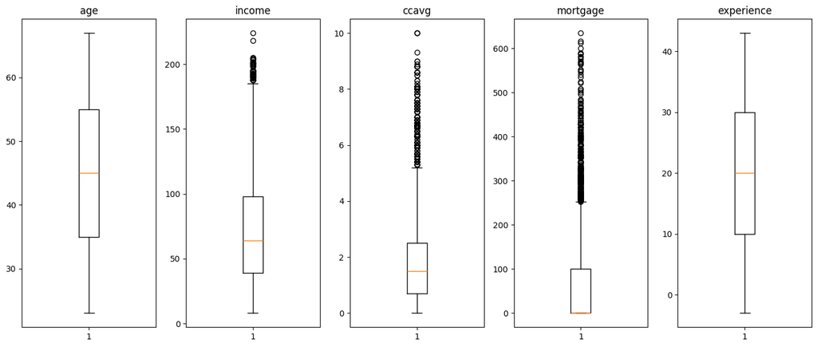

```python
# ================================
# Feature Handling/Cleaning
# ================================

# Define groups for later steps (no encoding or scaling applied here yet)
target_col = 'personal_loan'
binary_cols = ['securities_account','cd_account','online','creditcard']
cat_cols = ['education','family', 'region']
num_cols_continuous = ['age','income','ccavg','mortgage', 'experience']  # keep 'experience' only if you drop 'age'?
# ================================
# Outlier Detection (Boxplots)
# ================================
continuous_vars = [c for c in num_cols_continuous if c in df2.columns]
plt.figure(figsize=(14, 6))
for i, col in enumerate(continuous_vars, 1):
    plt.subplot(1, len(continuous_vars), i)
    plt.boxplot(df2[col], whis=1.5)
    plt.title(col)
plt.tight_layout()
plt.show()
```

```python
# Create a preprocessed copy for later modeling
df_pre = df2.copy()

# Scale continuous numeric features only
scale_cols = [c for c in num_cols_continuous if c in df_pre.columns]
scaler = StandardScaler()
df_pre_scaled_numeric = pd.DataFrame(
    scaler.fit_transform(df_pre[scale_cols]),
    columns=[f"{c}__scaled" for c in scale_cols],
    index=df_pre.index
)

# Join scaled columns back alongside raw features (no target leakage)
df_prepared = pd.concat([df_pre.drop(columns=scale_cols), df_pre_scaled_numeric], axis=1)

print("Prepared columns preview:")
sorted(df_prepared.columns)[:15], '...', len(df_prepared.columns)
```

```
Prepared columns preview:
```

```
(['age__scaled',
  'ccavg__scaled',
  'cd_account',
  'creditcard',
  'education',
  'experience__scaled',
  'family',
  'income__scaled',
  'mortgage__scaled',
  'online',
  'personal_loan',
  'region',
  'securities_account'],
 '...',
 13)
```